# Coursework Report

*N* removed NAs: 3

*N* removed typo: 1

*N* removed <18: 20

*N* total clean: 126

| Group | *N* | *M*<sub>age</sub> | *M*<sub>rating</sub> |
| --- | --- | --- | --- |
| Control | 63 | 21.03 | 5.64 |
| Experim | 63 | 20.81 | 7.20 |

**Main analysis results**

*t*(124) = -10.43, *p* < .001

[interactive chart not shown]

[figure not shown]

[interactive chart not shown]

# Coursework Report

Analysing Data, Spring 2020

# Methods

## Participants

111 undergraduates participated in the present study. The mean age of participants was 21.28 years. The standard deviation of participants’ ages was 1.99. Participants’ ages ranged from 19 to 28 years. Only partipants aged between 18 and 90 were included in the results.

Table 1 *Descriptive statistics: age by condition*

| Condition | *N* | % | *M*<sub>age_years</sub> | *SD*<sub>age_years</sub> |
| --- | --- | --- | --- | --- |
| control | 55 | 49.55 | 21.40 | 2.08 |
| experimental | 56 | 50.45 | 21.16 | 1.91 |

## Design

The current study examined whether colour influences percieved attractiveness. An independent measures design was used. The independent variable was the colour of the photo background. This was a categorical variable with two levels. Participants either viewed a black-and-white photo of a man on a white background (control condition), or red background (experimental condition). The dependent variable was the participants’ ratings of attractiveness. This was a continuous variable. Following a five second exposure to the photo, participants were asked to rate three face-valid items: “How attractive do you think the person is?”, “How pleasant is this person to look at?”, and “If I were to meet the person in this picture face to face, I would think he is attractive”. Participants rated these items on 9-point rating scales ranging from 1 (not at all attractive), to 9 (extremely attractive). Scores were averaged to form a composite index. We hypothesise that the background colour of a black-and-white photo of a moderately attractive man will influence ratings of his attractiveness. We will use a *t*-test to test the hypothesis.

# Results

We wanted to investigate whether the background colour of a black-and-white photo of a moderately attractive man would influence ratings of his attractiveness. We conducted an independent-measures *t*-test to do this. The analysis indicated that the photo with a red background was rated as more attractive (*M* = 5.83) than the photo with a white background (*M* = 4.35). This difference in means was significant (*M*<sub>diff</sub> = 1.48, 95% CI [-1.16, -1.8], *t* (109) = -9.14, *p* = <.001).

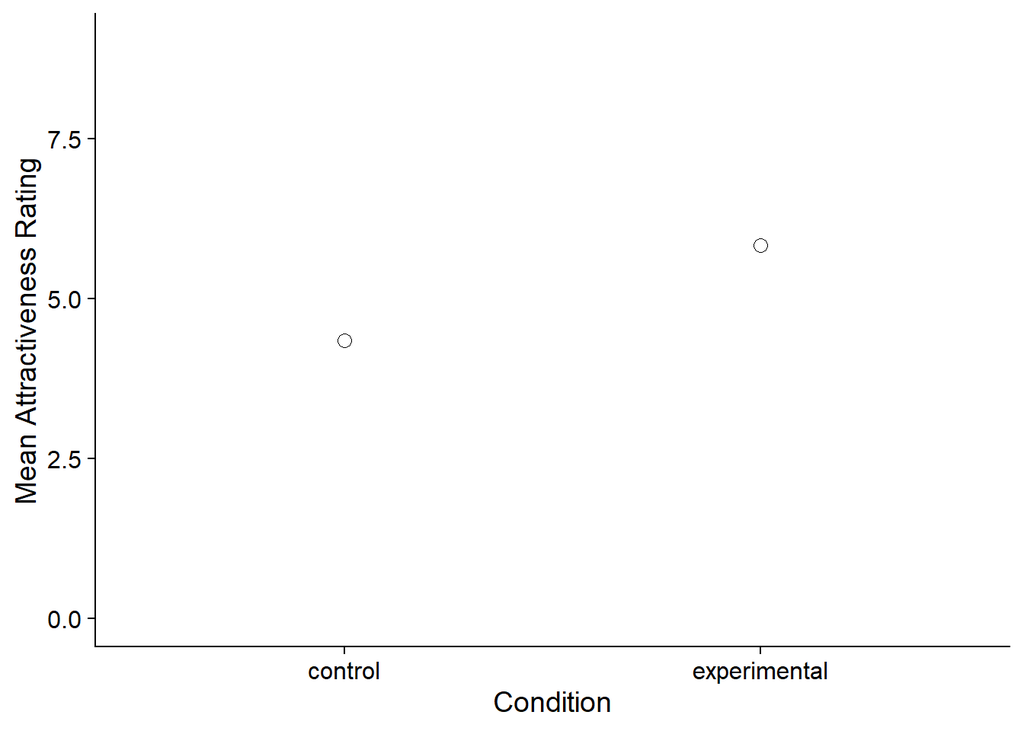

# Discussion

The present research aimed to explore whether colour influences percieved attractiveness. The results revealed that a black-and-white photo of a man on a red background was rated as more attractive than the same image on a white background. These findings support the hypothesis and suggest that colour, in particular red, influences percieved attractiveness.

The results support previous findings. For example, they extend Hurlbert and Ling’s (2007) research on sex differences in colour preference. Suggesting that women not only show a preference for red hues, but percieve men as more attractive in the context of the colour red. Further, the results offer valuable support for the colour-in-context theory which suggets that colour effects partner selection (Elliot & Maier, 2012). Notably, the present research findings replicate Elliot et al.’s (2010) red-effect. Here, the researchers also found that women who viewed a photo of a man on a red, relative to a white, background percived him to be more attractive. Therefore, the results are consistent with previous research, and help to extend certain ideas and theories. Importantly, these findings have practical utility to individuals as well as organisations interested in improving attractiveness and appeal of self or products. Particularly, meaning of colour in relation to attraction would be of marked interest to marketers, advertisers, and fashion and product designers.

It is important to note the possible limitations of the present research. Extraneous variables that extend past experimental control, such as how many hours of sleep participants got the night prior to the study, might impact on their mood or cognition, influencing ratings of attraction. Further, participants’ ratings may be affected by their interpretation of experimental objectives, thus facilitating demand characteristics. These limitations could be controlled for by using standardised procedures and involving a number of experimenters.

Future research could aim replicate the red-effect in a real-life setting. The act of being presented with, and rating a photo of a man is not a situation in which attractiveness would be normally be judged (Elliot et al.,2010). Subsequently, this limits the ecological validity, and may mean the observed red-effect was specific to information presented as a photo. For example, the red background might have dominated visual information available to participants more than would be typical in a real-life setting. Therefore, in future research, participants could make attractiveness judgements based on a face-to-face meeting with a man in a real-life setting. For instance, a speed-dating scenario in a cafe. Further, McKinney (2011) has cited that when an individual is attracted to someone, adrenaline is released into the body, heightening the heartrate. Hence, participants’ heartrates could be measured, in addition to attractiveness ratings, to provide supplementary empirical data. If the association between the colour red and attractiveness ratings can be clearly established in a real-life context with additional measures, this will verify the current study’s conclusions.

The present study aimed to explore whether colour influences perceived attractiveness. Results suggest that colour does have influence on attractiveness;the colour red increased attractiveness ratings of a photo of a man. This finding supports previous research in the same field, and may have beneficial consequences for both individuals and organisations.To further the current research, a similar study may be undertaken in a real-life setting in order to assess ecological validity and replicability.

# References

Elliot, A. & Maier, M. (2012). Colour-in-context theory. In Devine, A. & Plant, P.(Ed.) *Advances in experimental social psychology, 45*. New York, NY: Academic Press.

Elliot, A. J., Niesta Kayser, D., Greitmeyer, T., Lichtenfeld, S., Gramzow, R. H., Maier, M. A., & Liu, H. (2010). Red, rank, and romance in women viewing men. *Journal of Experimental Psychology: General, 139*(3), 399.

Hulbert, A. & Ling, Y. (2007). Biological components of sex differences in colour preference. *Current Biology, 17*(16), 632-625.

McKinney, K.(2011). The Effects of Adrenaline on Arousal and Attraction. *McKendree University Online Journal of Undergraduate Research, 17*. Retrieved from: https://www.mckendree.edu/academics/scholars/issue17/mckinney.htm